# 0413作業(No code)

統學

2021/4/12

## Problem 1

### (a)

從$Uniform(0,1)$抽樣計算積分式，所得平均數及變異數如下：

```
## [1] 0.52533583 0.05991423
```

若$f_0(x)=1$則與原式相同，服從$Uniform(0,1)$,計算平均數及變異數如下：
$$\int^{1}_{0}\frac{e^{-x}}{1+x^2}dx= \int^{1}_{0}\frac{e^{-x}/1+x^2}{1}1dx$$

```
## [1] "Mean of the values of simulation Integration: 0.524855942320723"
```

```
## [1] "Variance of the values of simulation Integration: 0.0601152584276106"
```

### (b)

若$f_0(x)=exp(-x)$，則變成服從$Exp(1)$分配並且積分分配值域為$[0,1]$，計算其平均數及變異數如下：
$$\int^{1}_{0}\frac{e^{-x}}{1+x^2}dx= \int^{1}_{0}\frac{e^{-x}/1+x^2}{e^{-x}}e^{-x}dx = \int^{1}_{0}\frac{1}{1+x^2}e^{-x}dx$$

```
## [1] "Mean of the values of simulation Integration: 0.59917234298382"
```

```
## [1] "Variance of the values of simulation Integration: 0.0612878170271518"
```

### (c)

#### (a),(b)小題有何差別？

- (a)小題為計算$g(x) = Uniform(0,1)$均勻分配的積分式，而(b)小題則是計算$g(x) = Exp(1)$指數分配的積分式,可發現指數分配在機率分布上沒有均勻分配來的平穩，可能來自我們限制x的值域落在$[0,1]$之間，原指數分配的值域為$[0,\infty]$，僅擷取指數分配中的一小段,導致偏誤較大。

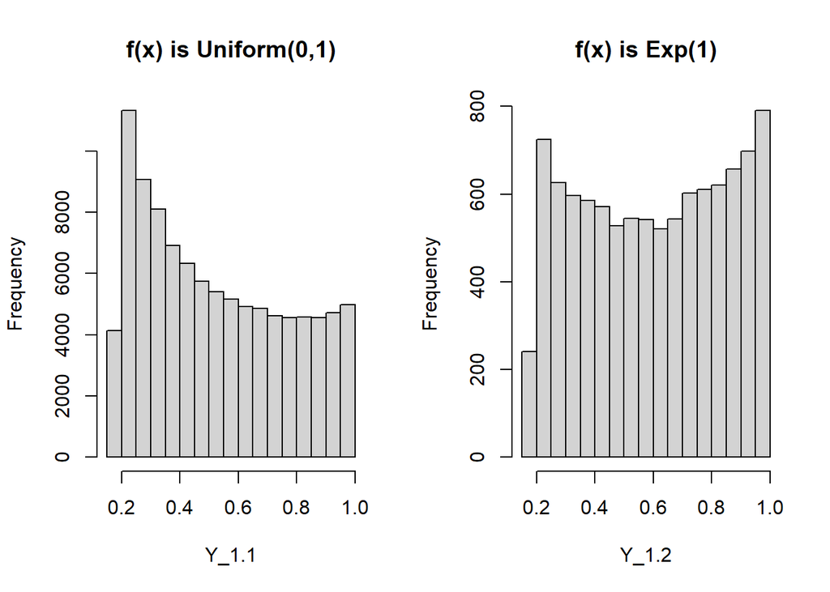

## Problem 2

### 建立模擬樣本

先根據$Y_i = \beta_0+X_i\beta_1+\epsilon_i$模擬數據

### (a)

可由下圖發現$\beta_1$在$M = 200$大樣本下其估計出的Variance極低約為0.001，從直方圖來看呈現鐘型曲線服從常態分配。

```
## [1] "Mean of beta_1: 2.00086840409782"
```

```
## [1] "Variance of beta_1: 0.00096465667958181"
```

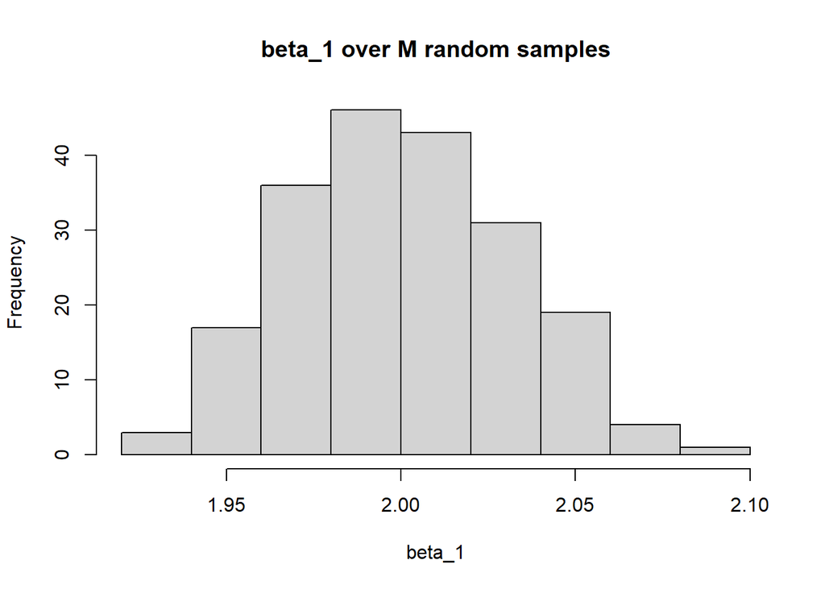

### (b)

可發現在估計$\beta_1$時，其值隨著每次模擬樣本的更動而有所不同，在這200個$\beta_1$的估計值中，全距大約0.156上下，而Boostrap後的平均數卻可讓$\beta_1$的估計值穩健地落在2。

```
## [1] "Maximum in the estimator of beta_1: 2.08548410994247"
```

```
## [1] "Minimum in the estimator of beta_1: 1.92855244270411"
```

```
## [1] "The range of the estimator of beta_1: 0.156931667238352"
```

### (c)

以$\hat{\theta} \sim N(\theta_0,n^{-1}\hat{\Sigma})$計算其變異數後平均，如下：

```
## [1] "Mean of the Asymptotic Variance of  beta_1: 0.0040090830103712"
```

計算$Empirical\ Variance$，算出200組$\hat{\beta_1}$的變異數，如下：

```
## [1] "Mean of the Empirical Variance of  beta_1: 0.00096465667958181"
```

可發現兩者在樣本數很大的情況下，變異數都非常小。

```
## [1] "Mean of the Asymptotic Variance of  beta_1: 0.0040090830103712"
```

```
## [1] "Mean of the Empirical Variance of  beta_1: 0.00096465667958181"
```

### (d)

第一種$Boostrap$為$Random\ X$的$Boostrap$，先從200組資料中，對每組的500筆資料重抽樣，可得新的200組樣本，對這200組$Boostrap \ Sample$計算$\hat{\beta_1}$，計算其變異數，如下：

```
## [1] "Mean of the estimator of beta_1 by Random x boostrap: 2.00753959826958"
```

```
## [1] "Variance of the estimator of beta_1 by Random x boostrap: : 0.00353469030345969"
```

第二種$Boostrap$為$Fixed\ X$的$Boostrap$，先將原200組資料配適可得殘差$\epsilon$，接著將殘差做200組重抽樣後，取出對應的X與其配適值，再將殘差加上配適值後得到新的$Y^*$，以$(X,Y^*)$計算$\hat{\beta_1}$，接著計算其變異數，如下：

```
## [1] "Mean of the estimator of beta_1 by Fixed x boostrap: 1.99604171567323"
```

```
## [1] "Variance of the estimator of beta_1 by Fixed x boostrap: 0.00318864235815397"
```

# (e)

$Perturbation\ Boostrap\ Sampling$為在$Likelihood$中多乘上一個機率分配$X$,並且$E(X)=1,Var(x)=1$，可得$\hat{\beta_1}$的$MLE$為$\frac{YXG^{(b)}}{XX^T}$，因此將$Y$乘上$G^{(b)}$，計算如下：  
### (a)小題加上擾動項

```
## [1] "Variance of Perturbation_beta_1 (a): 0.0268585508738842"
```

### (d)小題加上擾動項

```
## [1] "Variance of Perturbation_beta_1 (d) Random x: 0.0760376069539746"
```

```
## [1] "Variance of Perturbation_beta_1 (d) Fixed x: 0.0630605144545954"
```

觀察各題結果，發現使用$Perturbation\ Sampling$會使得變異數明顯大於其他方法所求，而其他方法在樣本數足夠大下，其變異數皆非常小。

```
## [1] "Variance of beta_1 in (a): 0.00096465667958181"
```

```
## [1] "Mean of the Asymptotic Variance of  beta_1 in (c): 0.0040090830103712"
```

```
## [1] "Mean of the Empirical Variance of  beta_1 in (c): 0.00096465667958181"
```

```
## [1] "Variance of the estimator of beta_1 by Random x boostrap in (d): 0.00353469030345969"
```

```
## [1] "Variance of the estimator of beta_1 by Fixed x boostrap in (d): 0.00318864235815397"
```

```
## [1] "Variance of Perturbation_beta_1 for (a) in (e): 0.0268585508738842"
```

```
## [1] "Variance of Perturbation_beta_1 for (d) Random x in (e): 0.0760376069539746"
```

```
## [1] "Variance of Perturbation_beta_1 for (d) Fixed x in (e): 0.0630605144545954"
```